# ComputeEffectualness

### Imports & setup

```python
import os
import sys
import shutil
import glob

import matplotlib.pyplot as plt
from matplotlib import rc
rc('text', usetex = True)

plt.rcParams.update(  # try to match font sizes of document
  {'axes.labelsize': 20,
   'axes.titlesize': 20,
   'legend.fontsize': 20,
   'xtick.labelsize': 20,
   'ytick.labelsize': 20,
   'text.usetex': True,
   'font.family': 'serif',
   'font.serif': ['palatino'],
   'savefig.dpi': 300
   })

%pylab inline

from igwn_ligolw import ligolw
from igwn_ligolw import table
from igwn_ligolw import lsctables
from igwn_ligolw import ilwd
from igwn_ligolw import utils as ligolw_utils

import pycbc.strain
import pycbc.psd
from pycbc.pnutils import mass1_mass2_to_mchirp_eta
from pycbc.waveform import td_approximants, fd_approximants
from pycbc.waveform import get_two_pol_waveform_filter, get_td_waveform
from pycbc import DYN_RANGE_FAC
from pycbc.types import FrequencySeries, zeros
from pycbc.filter import match, overlap, sigma, make_frequency_series
from pycbc.scheme import CPUScheme, CUDAScheme
from pycbc import pnutils

from gwnr.utils.types import make_padded_frequency_series
from gwnr.analysis import get_unique_hex_tag
import gwnr.analysis as DA

sys.path.append('/home/prayush.kumar/src/gwnr/bin/')
#sys.path.append('/home/prayush.kumar/local/venv/pycbc_master_enigma/src/gwnr/bin/')
```

```
Could not import ligolw in /home/prayush.kumar/src/GWNR/GWNR/Stats/FisherMatrixUtilities.pyc, LIGO XML tables wont be read
```

```python
run_dir = '/home/prayush.kumar/projects/template_banks/testing_banksim'
try: os.makedirs(run_dir)
except: pass
os.chdir(run_dir)
```

!ls

```python
!rm -fr *
```

```
rm: cannot remove ‘log’: Directory not empty
```

```python
!cp ../seed_banks/non_spinning/NonSpin_m1_10_0_50_0_m2_10_0_50_0_MM_0_95.xml bank.xml
# !cp ../seed_banks/non_spinning/NonSpin_m1_5_0_50_0_m2_5_0_50_0_MM_0_95.xml bank.xml
```

```python
!ls
```

[output not shown]

```python
def parse_match_file(mfile_name,
                     mvals_for_each_bank_point = {},
                     mvals_for_each_test_point = {}):
    if not os.path.exists(mfile_name):
        raise IOError("Provided file {} not found.".format(mfile_name))
    with open(mfile_name, 'r') as mfile:
        for line in mfile.readlines():
            line = line.split()
            btag, ptag = line[:2]
            if btag not in mvals_for_each_bank_point:
                mvals_for_each_bank_point[btag] = {}
            if ptag not in mvals_for_each_bank_point[btag]:
                mvals_for_each_bank_point[btag][ptag] = list([float(line[2]), float(line[3]), float(line[4])])
            if ptag not in mvals_for_each_test_point:
                mvals_for_each_test_point[ptag] = {}
            if btag not in mvals_for_each_test_point[ptag]:
                mvals_for_each_test_point[ptag][btag] = list([float(line[2]), float(line[3]), float(line[4])])
    return mvals_for_each_bank_point, mvals_for_each_test_point
```

```python
def get_all_matches_against_point(p, mvals_dict):
    mkeys = mvals_dict[p].keys()
    return np.array([mvals_dict[p][k] for k in mkeys], dtype=np.float128), mkeys
```

**ALGORITHM**

**Outline**:

1. Take as input `bank.xml` and a range of parameters + template model + signal model,
2. Generate test injections for that parameter range using the signal model,
3. Compute overlaps between each template in `bank.xml` and each of the test injections,
4. Maximize the overlap between each injection, and *all* templates in `bank.xml`,
5. Store those maximized overlaps, and templates corresponding to them.

**Simplification of algorithm for implementation**:

1. Read in the ini file, and call `gwnr_sample_parameter_space` to generate the requested injections. Store it as `inj.xml`.
2. Split `inj.xml` into sub-parts of `N_injection_per_job` test points each. Store them as `injection/injection*.xml`.
3. Similarly split `bank.xml` into sub-parts of `N_template_per_job` templates each. Store them as `bank/bank*.xml`.
4. Compute overlaps between injections `injection/injectionA.xml` and templates `bank/bankB.xml` and store them as `match-part/matchApartB.dat`. This is done using `gwnr_banksim`.
5. Use `gwnr_banksim_match_combine` to read in all overlap data from `match-part/matchApart*.dat` for `injection/injectionA.xml`; combine that information by maximizing the match between each injection and *all* templates! Store the output as `match/matchA.dat`.
6. Use `gwnr_banksim_collect_results` to collect all match values from `match/match*.dat` into a single file.

**Technical detail**

1. What information do we store in `match-part/matchApartB.dat`?
2. What information do we store in `match/matchA.dat`?
3. How do we uniquely tag injections and templates *precisely* using the information provided in these data files?

### Setup and execute banksim run

```python
!pwd
```

```
/home/prayush.kumar/projects/template_banks/testing_banksim
```

```python
with open("banksim.ini", 'a') as fout:
    fout.write("""\
[inspinj]
num-new-points = 5000
component-mass-min = 10.0
component-mass-max = 50.0
total-mass-max = 100.0
spin-component-min = 0
spin-component-max = 0
spin-mag-min = 0
spin-mag-max = 0
eccentricity-min = 0
eccentricity-max = 0
coa-phase-min = 0
coa-phase-max = 0
inclination-min = 0
inclination-max = 0
long-asc-nodes-min = 0
long-asc-nodes-max = 0
mean-per-ano-min = 0
mean-per-ano-max = 0
mchirp-window = 0
eccentricity-window = 0
verbose =


[executables]
inspinj = /home/prayush/src/gwnr/bin/gwnr_sample_parameter_space
banksim = /home/prayush/src/gwnr/bin/gwnr_banksim

[workflow]
accounting-group = ligo.dev.o3.cbc.explore.test
templates-per-job = 100
log-path = /usr1/prayush.kumar/
bank-file = /home/prayush.kumar/projects/template_banks/testing_banksim/bank.xml
injections-per-job = 10
templates-per-job = 10000


[banksim]
;processing-scheme = mkl
psd-model = aLIGOZeroDetHighPower
template-approximant = SEOBNRv4_ROM
proposal-approximant = SEOBNRv4_ROM
template-batch-size = 100
signal-batch-size = 100
low-frequency-cutoff = 20
sample-rate = 16384
signal-length = 64
mchirp-window = 0.10
verbose =
""")
```

```python
!ls
```

```
banksim.ini  bank.xml  log
```

```python
!rm bank banksim.da? banksim.sh inj.xml.xml log match injection banksim.dag* \
    match-part partial_results.sh plots *.sub submit.sh scripts sub.out inj.xml -fr
```

```python
!gwnr_create_banksim_workflow --config banksim.ini
```

[output not shown]

[output cut: 9 more lines]

```
2020-01-23 00:59:12,896 | INFO : 4200 points chosen
2020-01-23 00:59:13,275 | INFO : 4300 points chosen
2020-01-23 00:59:13,660 | INFO : 4400 points chosen
2020-01-23 00:59:14,050 | INFO : 4500 points chosen
2020-01-23 00:59:14,459 | INFO : 4600 points chosen
2020-01-23 00:59:14,861 | INFO : 4700 points chosen
2020-01-23 00:59:15,275 | INFO : 4800 points chosen
2020-01-23 00:59:15,691 | INFO : 4900 points chosen
2020-01-23 00:59:16,114 | INFO : Writing 5000 new points to inj.xml
2020-01-23 00:59:16,447 Splitting template bank
2020-01-23 00:59:18,715 Splitting injection file
2020-01-23 00:59:35,794 Creating DAG
2020-01-23 00:59:54,055 DO : 500 SKIP 0
2020-01-23 00:59:54,085 Creating submit script
2020-01-23 00:59:54,778 Done
```

```python
!ls && cat -n submit.sh
```

```
bank				       injection
banksim.dag			       inj.xml
banksim.dax			       log
banksim.ini			       match
banksim.sh			       match-part
bank.xml			       partial_results.sh
gwnr_banksim_collect_results.sub  plots
gwnr_banksim_match_combine.sub    scripts
gwnr_banksim_plots.sub	       submit.sh
gwnr_banksim.sub
     1	#!/bin/bash
     2	    condor_submit_dag banksim.dag
     3
```

```python
!./submit.sh >> sub.out
```

```python
!cat sub.out
```

```
Submitting job(s).
1 job(s) submitted to cluster 36348018.

-----------------------------------------------------------------------
File for submitting this DAG to HTCondor           : banksim.dag.condor.sub
Log of DAGMan debugging messages                 : banksim.dag.dagman.out
Log of HTCondor library output                     : banksim.dag.lib.out
Log of HTCondor library error messages             : banksim.dag.lib.err
Log of the life of condor_dagman itself          : banksim.dag.dagman.log

-----------------------------------------------------------------------
```

```python
!condor_rm 36347882
```

```
Couldn't find/remove all jobs in cluster 36347882
```

```python
!tail -n10 banksim.dag.dagman.out
```

```
01/23/20 01:10:41 Of 1002 nodes total:
01/23/20 01:10:41  Done     Pre   Queued    Post   Ready   Un-Ready   Failed
01/23/20 01:10:41   ===     ===      ===     ===     ===        ===      ===
01/23/20 01:10:41  1002       0        0       0       0          0        0
01/23/20 01:10:41 0 job proc(s) currently held
01/23/20 01:10:41 DAGMan Runtime Statistics: [ EventCycleTimeStd = 1.099006578522996; EventCycleTimeMax = 5.685035943984985; SubmitCycleTimeMin = 1.001358032226562E-05; SubmitCycleTimeAvg = 0.5562732588161122; SleepCycleTimeCount = 109.0; SubmitCycleTimeCount = 110.0; SubmitCycleTimeMax = 5.67791008…
01/23/20 01:10:41 Wrote metrics file banksim.dag.metrics.
01/23/20 01:10:41 Metrics not sent because of PEGASUS_METRICS or CONDOR_DEVELOPERS setting.
01/23/20 01:10:41 DAGMan Runtime Statistics: [ EventCycleTimeStd = 1.099006578522996; EventCycleTimeMax = 5.685035943984985; SubmitCycleTimeMin = 1.001358032226562E-05; SubmitCycleTimeAvg = 0.5562732588161122; SleepCycleTimeCount = 109.0; SubmitCycleTimeCount = 110.0; SubmitCycleTimeMax = 5.67791008…
01/23/20 01:10:41 **** condor_scheduniv_exec.36348018.0 (condor_DAGMAN) pid 1192333 EXITING WITH STATUS 0
```

```python
print('''USE WITH CARE ... ''')
#  !gwnr_force_success_from_submit_file gwnr_banksim.sub
```

```
USE WITH CARE ...
```

### Visualize test results

```python
from IPython.display import Image
```

```python
!ls plots
```

```
cum_hist.png		 m1-m2-mchirpdiff.png	  q-s2z-match90.png
hist-match-cum.png	 m1-m2-mchirpreldiff.png  q-s2z-match97.png
hist-match.png		 q-s1m-match.png	  q-s2z-match.png
hist-mchirp-diff.png	 q-s1z-match.png	  q-s2z-mchirpdiff.png
hist-mchirp-reldiff.png  q-s1z-mchirpdiff.png	  q-s2z-mchirpreldiff.png
inc-match.png		 q-s1z-mchirpreldiff.png  tm1-tm2-match.png
m1-m2-match.png		 q-s2m-match.png
```

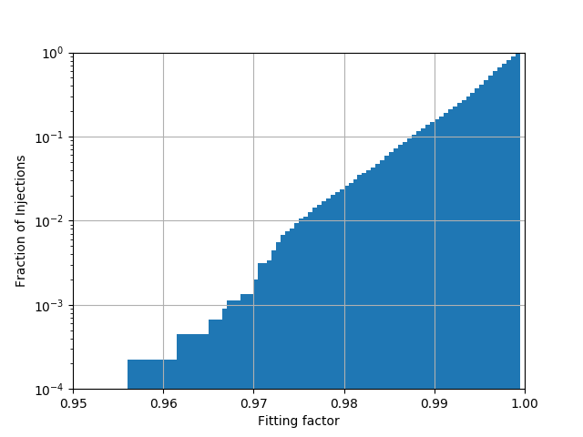

```python
Image('plots/cum_hist.png')
```

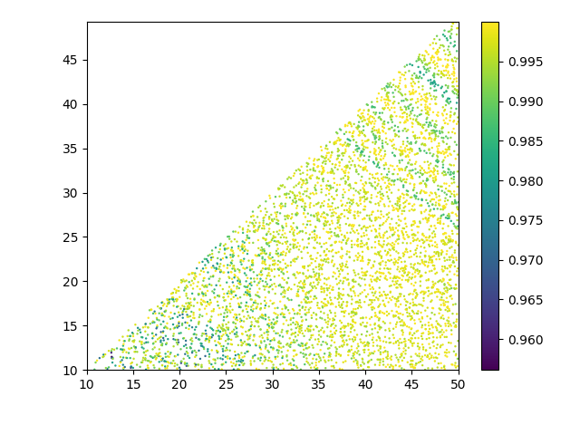

```python
Image('plots/m1-m2-match.png')
```

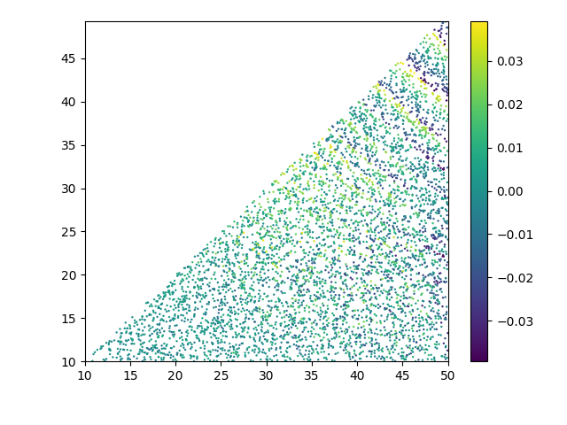

```python
Image('plots/m1-m2-mchirpreldiff.png')
```